# Scraping messy data

Martina Pocchiari

4/22/2020

This document is a step-by-step guide for scraping a website. We will write down a simple scraping algorithm that also handles errors in the webpage call. The main part of the document is dedicated to reshaping the data such that the tables are readable and adequate for statistical analysis and data visualization.

**DISCLAIMER**

Before you scrape any website, check the Terms of Service and make sure you are allowed to! DonBest does not allow scraping its contents with the purpose of reproducing or distributing its intellectual property. We will only use the contents for educational purposes.

### Loading Packages

We will need some packages that communicate with webpages and return their html structure and contents (`rvest, httr, xml2`) and some packages to clean, reshape, and visualize the data (`tidyverse, data.table`).

```r
##############################            ANALYSIS OF OPENING ODDS       ###########################

library(rvest)
library(httr)
library(xml2)
library(tidyverse)
library(data.table)
```

### Scraping a webpage

We are interested in obtaining the statistics from a sports betting website, DonBest.com. The statistics regard the betting odds and game results from Season 2018-2019 of the NCAA Basketball, Division I.

The url we are interested in scraping is `http://www.donbest.com/ncaab/odds/20181106.html`. The url contains a table with the results of the first day of matches of the NCAABB season 2018-19, November 6 2018 [^1].

```r
url <- 'http://www.donbest.com/ncaab/odds/20181106.html'
```

In order to import this information into R, we need to obtain the html structure and content of the webpage. We can do this with a GET request.

### Problem: What part of the webpage do I need?

Before I am able to obtain the statistics table that we need, we have to understand where in the webpage this information is stored. Usually, this kind of information is stored in a ‘table’ node. We can check what is the id of the node that we need by running “Inspect Element” on the webpage.

We can inspect the xml code of a valid url and see what’s inside:

```r
tmp <- httr::GET(url)

tmp %>% read_html()
```

```
## {html_document}
## <html xmlns="http://www.w3.org/1999/xhtml">
## [1] <head id="ctl00_pagehead">\n<title>NCAA Basketball Betting Odds, NCAA Tou ...
## [2] <body>\r\n\t<!--  -->\r\n    <form name="aspnetForm" method="post" action ...
```

I ran an Inspect Element command on my browser (Firefox) and identified the ID of the node that contains the table with the statistics. The node ID is “table”. We can then use `xml2` to extract and fill the table.

```r
tmp %>%
  read_html() %>%
  html_nodes(., 'table') %>%
  html_table(fill = T)
```

### Problem: How can I handle the errors from the GET request?

When I perform a GET request, it is not always 100% sure that I will obtain a valid response from the website (also called a class 200 response). In fact, I may get a class 500 error, which tells me that the website’s servers are not working properly; or maybe a class 400 error, which tells me that the page is unavailable, deleted, or that I don’t have permission to access it.

In the case of DonBest, this may happen when no games have been played on some calendar dates.

Before I move on with my scraping, I want my scraper function to tell me what is the status of my GET request. This is useful both for debugging and error tracing, and to avoid that I carry useless errors along the pipeline of code.

One way to incorporate error handling inside the basic scraping function is the `tryCatch()` function. It provides a mechanism for handling unusual conditions, including errors and warnings. Check `?tryCatch()` for more information on its functioning.

```r
Obtain_raw_day_table <- function(url) {

  x <-tryCatch({
    httr::GET(url)},
    error = function(e) e)

  if ("error" %in% class(x)) {
    print(x$message)
    print(x$call)
    return (NULL)
  }

  status <- httr::http_status(x)

  if (status$category == "Success") {

    if (x$status == 200) {
      httr::stop_for_status(x)

        x <- x %>%
          read_html() %>%
          html_nodes(., 'table')

        if (length(x %>% html_nodes(., 'img')) == 0) {

          x <- x %>%
            html_table(fill = T) %>%
            bind_rows() %>%
            mutate(url = url)

          return(x)

        } else {

          message('No info available')

          return(NULL)
        }

    } else {

      # category == "Success" but status != 200.

      print(status$message)
      return (NULL)

    }

  } else {

    if (x$status == 429) {

      stop('Too many requests, I am going to stop')

    } else {

      # status is not "Success"
      print(status$message)
      return (NULL)
    }
  }

  Sys.sleep(4)

}
```

With this code I either obtain a dataframe with the contents of the original url, or - if there were no games on a certain date, or if there were classes 500 or 400 errors - a NULL object, which will not be processed further. Here are 2 examples:

##### Valid URL Results

```r
x <- Obtain_raw_day_table(url)

head(x) %>%
  knitr::kable()
```

| X1 | X2 | X3 | X4 | X5 | X6 | X7 | X8 | X9 | X10 | X11 | X12 | X13 | X14 | X15 | X16 | X17 | X18 | X19 | X20 | X21 | url |
| --- | --- | --- | --- | --- | --- | --- | --- | --- | --- | --- | --- | --- | --- | --- | --- | --- | --- | --- | --- | --- | --- |
| COLLEGE BASKETBALL - Tuesday, November 6th | COLLEGE BASKETBALL - Tuesday, November 6th | COLLEGE BASKETBALL - Tuesday, November 6th | COLLEGE BASKETBALL - Tuesday, November 6th | COLLEGE BASKETBALL - Tuesday, November 6th | COLLEGE BASKETBALL - Tuesday, November 6th | COLLEGE BASKETBALL - Tuesday, November 6th | COLLEGE BASKETBALL - Tuesday, November 6th | COLLEGE BASKETBALL - Tuesday, November 6th | COLLEGE BASKETBALL - Tuesday, November 6th | COLLEGE BASKETBALL - Tuesday, November 6th | NA | NA | NA | NA | NA | NA | NA | NA | NA | NA | http://www.donbest.com/ncaab/odds/20181106.html |
| Rot | Opener | Team | Time | SC |  | Westgate | Mirage | Station | Pinnacle | SIA | SBG | BetUS | BetPhoenix | EasyStreet | Bovada | Jazz | Sportsbet | BookMaker | DSI | AceSport | http://www.donbest.com/ncaab/odds/20181106.html |
| 709710 | 130.0-25.0 | TowsonVirginia | 7:00 PM | 4273 | FINAL | 129.0-26.0 | 130.0-25.5 | 129.5-25.5 | 130.0-26.0 | 129.0-26.0 | 129.0-26.0 | 129.0-26.0 | 129.0-26.0 | 128.5-26.0 | 129.0-26.5 | 128.5-26.0 | 129.0-26.0 | 129.0-26.0 | 129.0-26.0 | 130.0-26.0 | http://www.donbest.com/ncaab/odds/20181106.html |
| 711712 | 146.0-17.0 | Wisc MilwaukeeBoston College | 7:00 PM | 5373 | FINAL | 147.5-16.0 | 147.5-16.5 | 147.0-16.5 | 146.5-16.0 | 147.0-15.5 | 147.0-16.0 | 147.0-16.0 | 147.0-16.0 | 147.0-16.0 | 147.0-16.0 | 147.0-16.0 | 147.0-16.0 | 147.5-15.5 | 147.0-16.0 | 147.0-16.0 | http://www.donbest.com/ncaab/odds/20181106.html |
| 713714 | 144.0-14.0 | Youngstown StatePittsburgh | 7:00 PM | 5369 | FINAL | 154.5-13.5 | 153.5-13.5 | 154.0-13.0 | 154.5-13.0 | 153.0-13.5 | 154.0-13.5 | 154.5-13.5 | 154.5-13.5 | 154.5-13.5 | 154.0-13.5 | 154.5-13.5 | 154.0-13.5 | 153.0-13.5 | 154.0-13.5 | 154.5-13.5 | http://www.donbest.com/ncaab/odds/20181106.html |
| 715716 | 148.0-16.0 | Illinois ChicagoNotre Dame | 7:00 PM | 6784 | FINAL | 147.0-11.5 | 146.5-11.5 | 146.5-11.5 | 146.0-11.5 | 146.5-11.5 | 146.5-11.0 | 146.5-11.5 | 146.5-11.5 | 146.5-11.0 | 146.0-11.5 | 146.5-11.0 | 146.5-11.0 | 146.5-11.5 | 146.5-11.5 | 146.5-11.5 | http://www.donbest.com/ncaab/odds/20181106.html |

##### Invalid URL Results

```r
url <- "http://www.donbest.com/ncaab/odds/20181101.html"
x <- Obtain_raw_day_table(url)
head(x)
```

#### Problem: Scraping the entire 2018/2019 NCAABB season

Now that we know that the scraper is able to handle errors, we can plan to scrape the results and statistics for the entire 2018-19 season. How can we do that?

One solution is to create a “database” of dates, that the scraping function can read and loop from.

```r
########### calendar of match dates ###########

months <- c(paste0('0', seq.int(1:9)), '10', '11', '12')
days <- c(paste0('0', seq.int(1:9)), as.character(seq.int(10,31)))

calendar <- expand.grid(months, days) %>%
  rename(month = Var1, day = Var2)

# I want November-December 2018
calendar_2018 <- calendar %>%
  filter(month %in% c('11', '12'))

# I want January-April 2019
calendar_2019 <- calendar %>%
  filter(month %in% c(paste0('0', seq.int(1:4))))
```

Pay attention to the fact that not all months have the same number of days. We need to write a small function to take care of those months.

```r
date_pieces <- function(month, day, year) {
  if (month %in% c('04', '06', '09', '11') & day == '31') {

    message('30 days month')

  } else if (month == '02' & (day == '29' | day == '30' |day == '31')) {

    message('28 days month')

  } else {

    return(paste0(year,month,day))
  }
}

dates_for_url_2018 <- purrr::map2(calendar_2018$month, calendar_2018$day, ~date_pieces(month = .x,day =  .y, year = '2018')) %>%
  plyr::compact(.) %>%
  purrr::flatten(.)

dates_for_url_2019 <- purrr::map2(calendar_2019$month, calendar_2019$day, ~date_pieces(month = .x,day =  .y, year = '2019')) %>%
  plyr::compact(.) %>%
  purrr::flatten(.)

dates_for_url <- append(dates_for_url_2018, dates_for_url_2019)

urls <- purrr::map(dates_for_url, ~paste0('http://www.donbest.com/ncaab/odds/', .x,'.html'))
```

Now that we have the dates, we can ask the basic scraper to loop over all of them.

#### Problems: How can we track the progress while we loop through the dates? How can we avoid getting blocked by the website?

One solution to the first problem: we can keep a list of urls that we have already looped over in the environment, and add a visual counter in the form of a message. We will come back to saving intermediate progress later.

The second problem is harder. The problem is that if we make too many quick requests, the website will realize that we are employing a scraper. Unable to verify our intentions, the webiste will block our attempts. One solution here is to ask the system to stop for a few seconds before looping to the next calendar date. The sleep time cannot be fixed - that will also be recognized as a scraping attempt by a robot. We need to add some random component to mimick a “quasi-human” behavior.

Let’s try with the first 5 urls.

```r
urls_done <- list()

########### START COLLECTION ###########

urls_to_do <- urls[!(urls %in% urls_done)]

raw_tables_20182019 <- purrr::map(urls_to_do[1:5], ~{
  print(paste0('url # ', which(urls == .x)))
  urls_done <<- append(urls_done, .x)
  Sys.sleep(sample(5:10, size = 1, replace = F))
  Obtain_raw_day_table(.x)
})
```

```
## [1] "url # 1"
```

```
## No info available
```

```
## [1] "url # 2"
## [1] "url # 3"
```

```
## No info available
```

```
## [1] "url # 4"
## [1] "url # 5"
```

```
## No info available
```

```r
raw_tables_20182019 %>%
  bind_rows() %>%
  head(n = 5) %>%
  knitr::kable()
```

| X1 | X2 | X3 | X4 | X5 | X6 | X7 | X8 | X9 | X10 | X11 | X12 | X13 | X14 | X15 | X16 | X17 | X18 | X19 | X20 | X21 | url |
| --- | --- | --- | --- | --- | --- | --- | --- | --- | --- | --- | --- | --- | --- | --- | --- | --- | --- | --- | --- | --- | --- |
| COLLEGE BASKETBALL - Saturday, December 1st | COLLEGE BASKETBALL - Saturday, December 1st | COLLEGE BASKETBALL - Saturday, December 1st | COLLEGE BASKETBALL - Saturday, December 1st | COLLEGE BASKETBALL - Saturday, December 1st | COLLEGE BASKETBALL - Saturday, December 1st | COLLEGE BASKETBALL - Saturday, December 1st | COLLEGE BASKETBALL - Saturday, December 1st | COLLEGE BASKETBALL - Saturday, December 1st | COLLEGE BASKETBALL - Saturday, December 1st | COLLEGE BASKETBALL - Saturday, December 1st | NA | NA | NA | NA | NA | NA | NA | NA | NA | NA | http://www.donbest.com/ncaab/odds/20181201.html |
| Rot | Opener | Team | Time | SC |  | Westgate | Mirage | Station | Pinnacle | SIA | SBG | BetUS | BetPhoenix | EasyStreet | Bovada | Jazz | Sportsbet | BookMaker | DSI | AceSport | http://www.donbest.com/ncaab/odds/20181201.html |
| 515516 | 136.5-9.0 | Eastern MichiganNortheastern | 3:00 PM | 6781 | FINAL | 136.0-7.5 | 136.5-7.5 | 137.0-7.5 | 135.5-7.0 | 136.0-7.5 | 136.0-7.5 | 136.0-7.5 | 136.0-7.5 | 136.0-7.0 | 136.0-7.5 | 136.0-7.0 | 136.0-7.5 | 135.5-7.5 | 136.0-7.5 | 136.0-7.5 | http://www.donbest.com/ncaab/odds/20181201.html |
| 517518 | 127.0-10.5 | James MadisonOld Dominion | 7:00 PM | 4267 | FINAL | 127.5-11.0 | 127.5-11.0 | 127.0-11.5 | 127.5-11.0 | 127.5-11.0 | 127.5-11.0 | 127.5-11.0 | 127.5-11.0 | 127.0-11.0 | 127.0-11.0 | 127.0-11.0 | 127.5-11.0 | 127.5-10.5 | 127.5-11.0 | 127.5-11.0 | http://www.donbest.com/ncaab/odds/20181201.html |
| 519520 | 149.5-3.0 | LouisvilleSeton Hall | 12:00 PM | 7065 | FINAL | 147.5-3.5 | 148.0-3.5 | 148.0-3.5 | 148.0-3.0 | 147.5-3.5 | 147.5-3.0 | 147.5-3.0 | 147.5-3.0 | 147.5-3.0 | 148.0-3.0 | 147.5-3.0 | 147.5-3.0 | 147.5-3.0 | 147.5-3.0 | 147.5-3.0 | http://www.donbest.com/ncaab/odds/20181201.html |

#### Problem: Sometimes, the calls don’t work

DonBest sometimes does not behave as expected. Even if some team has played on a certain date, DonBest may return an empty page. But that information is important for our analysis. So we will give the website the benefit of the doubt: each time it returns an empty page, we will ask the scraper to run again, just in case DonBest was not behaving in the right way. Otherwise, we’ll just move on.

```r
Iter_for_null_results <- function(url) {

  x <<- Obtain_raw_day_table(url)

  date <- gsub(x = url, pattern = 'http://www.donbest.com/ncaab/odds/|\\.html', replacement = '')

  # If x is null: try once more, and if it's still null, give message

  counter <- 0

  while(is.null(x) & counter < 3) {

    message(paste0("x is null, retry # ", counter))

    x <<- Obtain_raw_day_table(url)
    Sys.sleep(sample(4:6, size = 1))
    counter <- counter + 1

  }

   if (is.null(x)) {
      message('No info available')

      return(NULL)

    } else {

      return(x)

    }

}

urls_done <- list()

########### START COLLECTION ###########

urls_to_do <- urls[!(urls %in% urls_done)]

raw_tables_20182019 <- purrr::map(urls_to_do[1:5], ~{
  print(paste0('url # ', which(urls == .x)))
  urls_done <<- append(urls_done, .x)
  Sys.sleep(sample(5:10, size = 1, replace = F))
  Iter_for_null_results(.x)
})


raw_tables_20182019 %>%
  bind_rows() %>%
  head(n = 5) %>%
  knitr::kable()
```

[output not shown]

So the basic scraper works; but the output is very messy. There are column headers everywhere, the statistics referring to a pair of opponent teams are now stored into only 1 column each (instead of 2). We need to do some cleaning and reshaping before being able to work with this.

### Data Cleaning and Reshaping

Because we need to loop over more than 100 calendar dates, the best way to clean and reshape data is *right after* each iteration comes out of the basic scraper.

#### Problems

Here we are going to have many problems. Namely:

- **How to deal with empty or weird rows?** Sometimes, DonBest will deliver this symbol ‘–’ instead of a score. Other times, the cells with the odds will be empty. We need to disregard those entries because they are unusable, but we need to keep track of the fact that these errors have occurred.
- **How can we divide the opening odds of the first (home) team from those of the opponent (away) team?** Right now, they are clumped together in one cell.
- **What if the opening odds contain a ‘PK’ result?** A PK result literally means “Pick one”. It means that the bettor can pick either of the teams to bet upon - they have approximately the same probability of victory. This translates into a “0.00” money line - that is, if you bet 1 dollar and one of the teams wins, you can at most get your dollar back, nothing more but nothing less.
- **What if the format of the opening odds is not uniform?** Sometimes, the opening odds will be delivered such that they only have one digit after the decimal point (i.e. 150.0) and other times with two digits after the decimal point (i.e. 150.00). We need to split them in the correct format between home and away team odds.

The following code takes care of all of these problems (and probably a few more):

```r
Obtain_clean_day_table <- function(x) {

  if (is.null(x)) {

    return(NULL)

  } else if (length(x) > 0 & class(x) == "data.frame") {

    date <- gsub(x = x$url, pattern = 'http://www.donbest.com/ncaab/odds/|\\.html', replacement = '')[1]

    message("Table with nrow > 1 successful")

    colnames(x) <- x[2,]
    colnames(x) <- ifelse(colnames(x) == '', 'Game_stage', colnames(x))

    x <- x %>%
      slice(-c(1:2)) %>%
      filter(Game_stage != '' &
               !(Game_stage %like% 'COLLEGE BASKETBAL') & Opener != '--' & (Time %like% 'PM|AM'))

    # Do the opening odds contain a 'PK' result?

    if (any(grepl('PK', x = x$Opener))) {

      # Excluding the PK result, do the opening odds have 1 or 2 digits after the point?

        # how many digits are there after the point at max?
        nchrcts <- max(nchar(gsub(x$Opener[-grep(x = x$Opener, 'PK')],
                   replacement = '', pattern = '^(?:[^\\.]*\\.){2}')))

        if (nchrcts > 3) {
          nchrcts <- min(nchar(gsub(x$Opener[-grep(x = x$Opener, 'PK')],
                                    replacement = '', pattern = '^(?:[^\\.]*\\.){2}')))
        }

        # Substitute PK with a 0-point-as many zeros as the digits after the point
        x$Opener <- gsub('PK', replacement = paste0('0.',
                                                    paste(rep(0, nchrcts), collapse = '')),
                         x$Opener)

      }

    x <- x %>%
      mutate(opening_odds = ifelse(
        # if after the second symbol there is more than 1 digit but less than 3,
        nchar(gsub(Opener, replacement = '', pattern = '^(?:[^\\.]*\\.){2}')) > 1 & nchar(gsub(Opener, replacement = '', pattern = '^(?:[^\\.]*\\.){2}')) <= 3,
        #split after two numbers that are preceded by a symbol
              strsplit(Opener, "(?<=\\.[0-9][0-9])", perl = TRUE),
        #else split after one number that is preceded by a symbol
              strsplit(Opener, "(?<=\\.[0-9])", perl = TRUE)),
             date = date)

    if ('opening_odds' %in% colnames(x) & all(lengths(x$opening_odds) == 2)) {

      x$opening_odds <- purrr::map(x$opening_odds, ~set_names(.x, c("home_opening_odds", "away_opening_odds")))

    } else if (any(lengths(x$opening_odds) == 1)) {

      x$exceptions[lengths(x$opening_odds) != 2] <- 'Opening odds length was != 2'

      x$opening_odds[lengths(x$opening_odds) == 1] <- lapply(x$opening_odds[lengths(x$opening_odds) == 1], function(x) c(x, NA))

      x$opening_odds <- purrr::map(x$opening_odds, ~set_names(.x, c("home_opening_odds", "away_opening_odds")))

    } else {

      x$exceptions[lengths(x$opening_odds) != 2] <- 'Opening odds length was != 2'

      x$opening_odds[lengths(x$opening_odds) != 2] <- lapply(x$opening_odds[lengths(x$opening_odds) > 2],
                                                            function(x) c(NA, NA))

      x$opening_odds <- purrr::map(x$opening_odds, ~set_names(.x, c("home_opening_odds", "away_opening_odds")))

    }

    return(x)

  } else {

    message("there is some problem and the GET request didn't work")

    return(NULL)
  }
}
```

Let’s test this code with our first 5 urls.

```r
raw_tables_20182019 <- raw_tables_20182019 %>%
  bind_rows()

clean_tables_20182019 <- Obtain_clean_day_table(raw_tables_20182019)
```

```
## Table with nrow > 1 successful
```

```r
head(clean_tables_20182019 %>% select(Rot, Team, Opener, opening_odds, date), n = 5)
```

```
##      Rot                         Team     Opener opening_odds     date
## 1 515516 Eastern MichiganNortheastern  136.5-9.0  136.5, -9.0 20181201
## 2 517518    James MadisonOld Dominion 127.0-10.5 127.0, -10.5 20181201
## 3 519520         LouisvilleSeton Hall  149.5-3.0  149.5, -3.0 20181201
## 4 521522              CornellSyracuse 139.0-22.5 139.0, -22.5 20181201
## 5 523524                OaklandXavier 150.0-17.0 150.0, -17.0 20181201
```

#### Problem: Extract the opening odds from the list of odds

The odds are now stored as lists in a column. We need to extract them and transform them into two separate columns.

```r
extract_odds_from_list <- function(clean_table) {

  if(is.null(clean_table)) {
    return(NULL)

  } else {

  clean_table <- bind_cols(clean_table,
                                 bind_rows(purrr::map2(clean_table$Rot,
                                                       clean_table$opening_odds,
                                                       ~mutate(Rot = .x, bind_rows(.y))))
  ) %>%
    select(-opening_odds)

  return(clean_table)

  }

}
```

We can test this code with our dataframe:

```r
table_with_odds <- extract_odds_from_list(clean_tables_20182019)

head(table_with_odds %>%
       select(Rot, Team, Opener, home_opening_odds, away_opening_odds, date), n = 5) %>%
  knitr::kable()
```

| Rot | Team | Opener | home_opening_odds | away_opening_odds | date |
| --- | --- | --- | --- | --- | --- |
| 515516 | Eastern MichiganNortheastern | 136.5-9.0 | 136.5 | -9.0 | 20181201 |
| 517518 | James MadisonOld Dominion | 127.0-10.5 | 127.0 | -10.5 | 20181201 |
| 519520 | LouisvilleSeton Hall | 149.5-3.0 | 149.5 | -3.0 | 20181201 |
| 521522 | CornellSyracuse | 139.0-22.5 | 139.0 | -22.5 | 20181201 |
| 523524 | OaklandXavier | 150.0-17.0 | 150.0 | -17.0 | 20181201 |

#### Problem: Convert money line odds into probabilities of victory and separate scores between home and away team

These opening odds mean little to a non-U.S. audience. They can be better interpreted if converted into probabilities.

```r
American_odds_to_fractional <- function(x) {
  Fractional <- ifelse(x > 0, x/100, -100/x)
  return(Fractional)
}

American_odds_to_percentage <- function(x) {
  Percentage <- ifelse(x > 0, (100/(x+100))*100, ifelse(x < 0, ((-1*x)/((-1*x)+100))*100, 50))
  return(Percentage)
}
```

Moreover, we have the same problem with the scores as we had with the odds: the scores from 2 teams are glued together in a single column.

#### Problem: How to split the team scores into 2 columns?

Recall that these are professional basketball players: their teams usually score double digits, but they can easily score more than 100 points per game. How can we split the score column if we don’t know whether a team scored double or triple digits? And if we know the digits, how do we know *which* of the teams scored double, which scored triple?

The code below takes care of this problem. The solution is in the fact that:

- If both teams scored double digits, the score has 4 digits.
- If one of the teams scored double digits and one triple, the score has 5 digits.
- If both teams scored triple digits, the score has 6 digits.
- The maximum triple-digit score ever achieved in the NBA is 186 points, and it is highly unlikely that any NCAA team will score above that record.

```r
convert_odds_and_scores <- function(table_with_odds) {

  if(is.null(table_with_odds)) {

    return(NULL)

  } else {

  if (!('home_opening_odds' %in% colnames(table_with_odds)) | !('away_opening_odds' %in% colnames(table_with_odds))) {

    message('columns not found, run extract_odds_from_list() first')

    x$exceptions <- c('columns for opening_odds not found')

    return(table_with_odds)

  } else {

  table_with_odds <- table_with_odds %>%
    mutate_at(c('home_opening_odds','away_opening_odds'), as.numeric) %>%
    # converting odds and rescaling probabilities
    mutate(FR_home_odds = American_odds_to_percentage(home_opening_odds),
           FR_away_odds = American_odds_to_percentage(away_opening_odds)) %>%
    rowwise() %>%
    mutate(Pr_home_odds_scaled = FR_home_odds/(FR_home_odds + FR_away_odds),
           Pr_away_odds_scaled = FR_away_odds/(FR_home_odds + FR_away_odds),
           difference_scaled = Pr_home_odds_scaled-Pr_away_odds_scaled) %>%
    # scores
    mutate(SC = as.character(SC),
           # if the score is made of 4 or less digits, then split into two pairs of two digits
           scores_home = ifelse(nchar(SC) <= 4, stringr::str_sub(SC, start = 1, end = 2),
                                # if the score has more than 4 digits, and the first 3 digits are higher than 180 (a very high score in BB)
                                # then the home team made double digits, and the away team made triple
                                # else, the home team made triple digits
                                ifelse(stringr::str_sub(SC, end = 3) > 180, stringr::str_sub(SC, end = 2), stringr::str_sub(SC, end = 3))),
           # for the away team, select the digits of the score not included in score_home.
           scores_away = stringr::str_remove(SC, pattern = scores_home),
           scores_home = as.numeric(scores_home),
           scores_away = as.numeric(scores_away),
           difference_score = scores_home - scores_away) %>%
    distinct(Rot, Team, date, Time, Game_stage, home_opening_odds, away_opening_odds,
             #FR_home_odds, FR_away_odds,
             Pr_home_odds_scaled, Pr_away_odds_scaled,
             difference_scaled, scores_home, scores_away, exceptions)


    return(table_with_odds)
    }
  }
}
```

We can test this code here:

```r
final_table <- convert_odds_and_scores(table_with_odds)

head(final_table %>%
       select(Rot, Team, scores_home, scores_away, home_opening_odds, away_opening_odds, date), n = 5) %>%
  knitr::kable()
```

| Rot | Team | scores_home | scores_away | home_opening_odds | away_opening_odds | date |
| --- | --- | --- | --- | --- | --- | --- |
| 515516 | Eastern MichiganNortheastern | 67 | 81 | 136.5 | -9.0 | 20181201 |
| 517518 | James MadisonOld Dominion | 42 | 67 | 127.0 | -10.5 | 20181201 |
| 519520 | LouisvilleSeton Hall | 70 | 65 | 149.5 | -3.0 | 20181201 |
| 521522 | CornellSyracuse | 55 | 63 | 139.0 | -22.5 | 20181201 |
| 523524 | OaklandXavier | 63 | 73 | 150.0 | -17.0 | 20181201 |

### Loop the sequence and save intermediate results

Now that we have the base code ready, we can write a wrapper function that starts from the URL and returns the final table. It also needs to save the results from each URL separately, so that if the scraper stops halfway, you will still be able to access the last bit of data that worked out fine.

```r
scrape_complete <- function(url) {

  date <- gsub(x = url, pattern = 'http://www.donbest.com/ncaab/odds/|\\.html', replacement = '')

  message('Obtaining clean table from URL')

  raw_table <- Iter_for_null_results(url)

  clean_table <- Obtain_clean_day_table(raw_table)

  message('Extracting odds from table')

  table_with_odds <- extract_odds_from_list(clean_table)

  if (!('home_opening_odds' %in% colnames(table_with_odds)) |
      !('away_opening_odds' %in% colnames(table_with_odds))){

    message('Running code once more to obtain odds columns')

    clean_table <- Obtain_clean_day_table(url)
    table_with_odds <- extract_odds_from_list(clean_table)
  }

  message('Converting odds and scores')

  final_table <- convert_odds_and_scores(table_with_odds)

  if(!is.null(final_table)) {

    message('saving locally')

    save(final_table, file = paste0('Data/Opening_odds_raw/', date,'.RData'))

    return(final_table)

  } else {
    return(NULL)
  }

}
```

This code can be used to loop over the calendar dates and return the final table directly.

```r
urls <- purrr::map(dates_for_url, ~paste0('http://www.donbest.com/ncaab/odds/', .x,'.html'))

urls_done <- list()

urls_to_do <- urls[!(urls %in% urls_done)]

final_table <- purrr::map(urls_to_do, ~{
  print(paste0('url # ', which(urls == .x)))
  urls_done <<- append(urls_done, .x)
  Sys.sleep(sample(5:10, size = 1, replace = F))
  scrape_complete(.x)
})
```

### Some simple analyses of the results

#### Distribution by Team Category

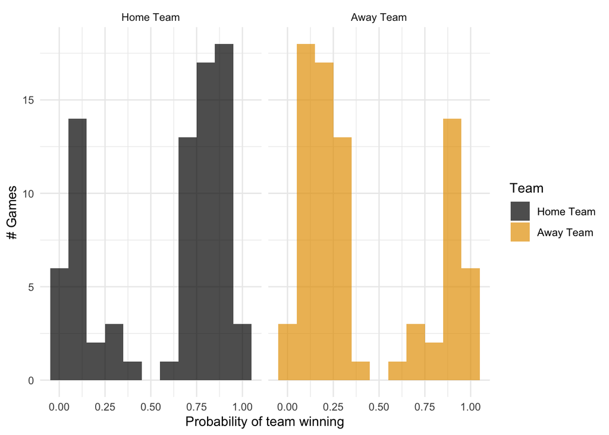

```r
# The palette with black:
cbbPalette <- c("#000000", "#E69F00", "#56B4E9", "#009E73", "#F0E442", "#0072B2", "#D55E00", "#CC79A7")


final_table %>%
  filter(!is.na(Pr_home_odds_scaled) & !is.na(Pr_away_odds_scaled)) %>%
  gather(., key = 'variable', value = 'Pr_Team_Wins', Pr_home_odds_scaled, Pr_away_odds_scaled) %>%
  mutate(variable = factor(variable,
                           levels = c('Pr_home_odds_scaled','Pr_away_odds_scaled'),
                           labels = c('Home Team', 'Away Team'))) %>%
  ggplot(aes(x = Pr_Team_Wins, fill = variable)) +
  geom_histogram(alpha = .7, binwidth = .10) +
  facet_grid(.~variable) +
  scale_fill_manual(values = cbbPalette) +
  labs(x = 'Probability of team winning', y = '# Games', fill = 'Team') +
  theme_minimal()
```

We can also divide the opening odds into bigger probability bins, for example:

- 0-33% (less than 1/3 chance of victory)
- 33-45% chance of victory
- 45-55% chance of victory (more or less balanced)
- 55-66% chance of victory (about 2/3 chance)
- 66-100% chance of victory (more than 2/3 chance)

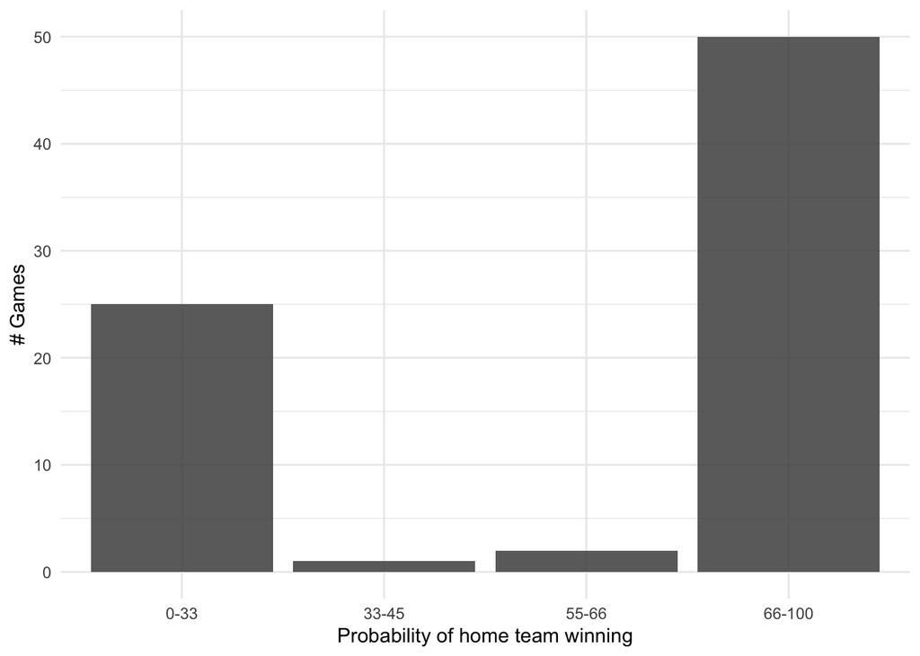

```r
final_table %>%
  filter(!is.na(Pr_home_odds_scaled) & !is.na(Pr_away_odds_scaled)) %>%
  mutate(prob_binned = ifelse(Pr_home_odds_scaled <= .55 & Pr_home_odds_scaled >= .45, '45-55',
                              ifelse(Pr_home_odds_scaled < .45 & Pr_home_odds_scaled >= .33, '33-45',
                                     ifelse(Pr_home_odds_scaled < .33 & Pr_home_odds_scaled >= 0, '0-33',
                                            ifelse(Pr_home_odds_scaled <= .66 & Pr_home_odds_scaled > .55, '55-66',
                                                   ifelse(Pr_home_odds_scaled < 1 & Pr_home_odds_scaled > .66, '66-100', NA)
                                                   )
                                            )
                                     )
                              )
         ) %>%
  ggplot(aes(x = prob_binned)) +
  geom_histogram(alpha = .9, stat = 'count') +
  labs(x = 'Probability of home team winning', y = '# Games') +
  theme_minimal()
```

#### Distribution of the Difference between Home and Away Odds

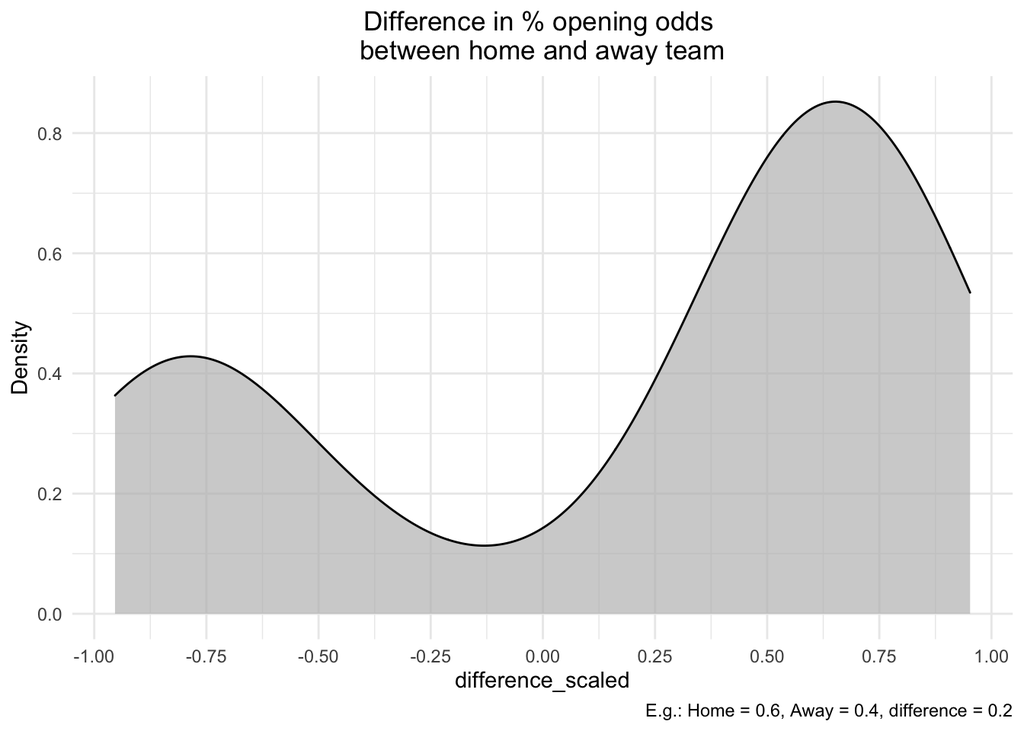

```r
final_table %>%
    filter(!is.na(Pr_home_odds_scaled) & !is.na(Pr_away_odds_scaled)) %>%
    ggplot(aes(x = difference_scaled)) +
    geom_density(alpha = .7, fill = 'grey') +
    # geom_vline(xintercept = -0.1, color = 'red', linetype = 3) +
    # geom_vline(xintercept = 0.1, color = 'red', linetype = 3) +
    scale_x_continuous(breaks = seq(-1, 1, 0.25)) +
    theme_minimal() +
    labs(title = 'Difference in % opening odds \nbetween home and away team', y = 'Density',
         caption = 'E.g.: Home = 0.6, Away = 0.4, difference = 0.2') +
    theme(plot.title = element_text(hjust = 0.5))
```

#### Distribution of Opening Odds and Game Scores

The game score difference is calculated as *Home team final score* - *Away team final score*. Differences in scores around 0 mean that the teams almost tied.

[figure not shown]

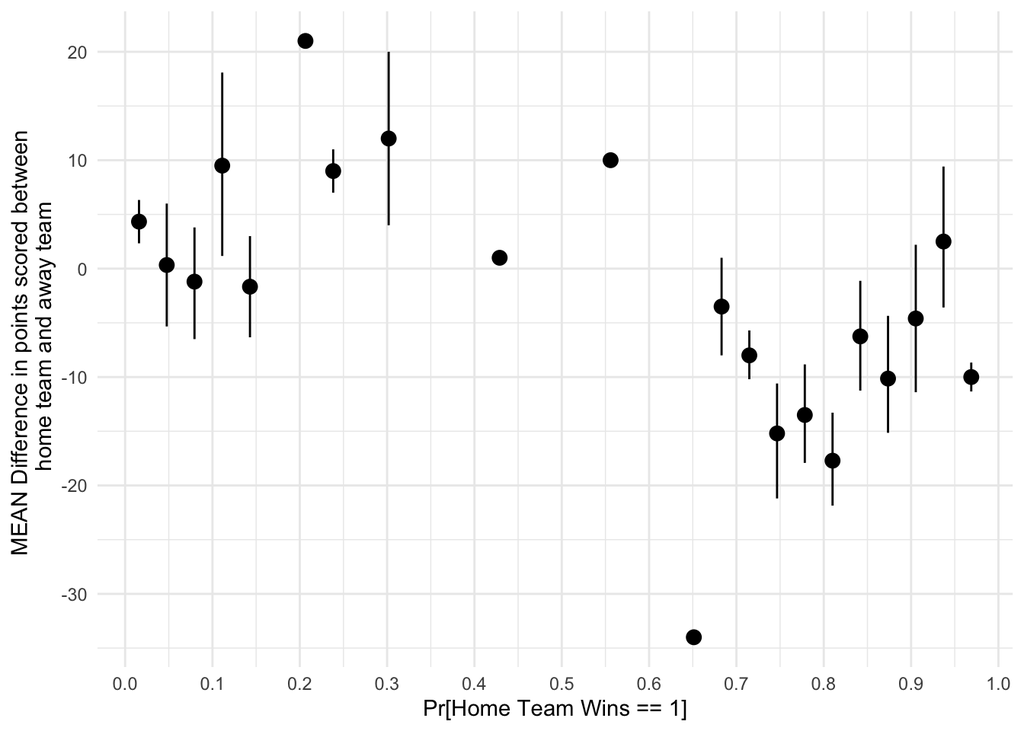

```r
final_table %>%
  filter(!is.na(Pr_home_odds_scaled) & !is.na(Pr_away_odds_scaled)) %>%
  mutate(score_difference = scores_home - scores_away) %>%
  gather(., key = 'variable', value = 'Pr_Team_Wins', Pr_home_odds_scaled, Pr_away_odds_scaled) %>%
  gather(., key = 'variable_score', value = 'Score', scores_home, scores_away) %>%
  mutate(variable = factor(variable,
                           levels = c('Pr_home_odds_scaled','Pr_away_odds_scaled'),
                           labels = c('Pr[Home Team Wins]', 'Pr[Away Team Wins]')),
         variable_score = factor(variable_score,
                           levels = c('scores_home','scores_away'),
                           labels = c('Score Home Team', 'Score Away Team'))) %>%
  filter(variable == 'Pr[Home Team Wins]') %>%
  ggplot(aes(x = Pr_Team_Wins, y = score_difference)) +
  stat_summary_bin(fun.data = mean_cl_boot, color = 'black', size = 0.5) +
  stat_summary_bin(fun.y = mean, size = 3, geom = 'point') +
  scale_x_continuous(breaks = seq(0, 1, 0.10)) +
  scale_y_continuous(breaks = seq(-60, 50, 10)) +
  theme_minimal() +
  # annotate("rect", xmin = .2, xmax = .8, ymin = -50, ymax = 15, alpha = .3) +
  #annotate("rect", xmin = .4, xmax = .6, ymin = -50, ymax = 15, alpha = .3) +
  labs(x = 'Pr[Home Team Wins == 1]', y = 'MEAN Difference in points scored between \n home team and away team')
```

[^1]: https://www.google.com/search?q=ncaa+basketball+2018+season+start